# 14

Рафи Кази ар

НКАбд-03-24

1032238132@pfur.ru

### **Задание 1: Упрощенный механизм семафоров**

Это задание реализует концепцию **мьютекса** (взаимоисключающей блокировки) с использованием файла в качестве семафора.

**Листинг скрипта semaphore.sh:**

#!/bin/bash
# Аргументы: $1 - время ожидания (t1), $2 - время использования (t2)
t1=$1
t2=$2
semaphore_file="/tmp/lab12_semaphore.lock"
# Функция для ожидания освобождения ресурса
wait_for_resource() {
local wait_time=0
# Проверяем существование файла-семафора каждую секунду
while [ -f "$semaphore_file" ] && [ $wait_time -lt $t1 ]; do
echo "Процесс $$: Ресурс занят. Ожидание... ($wait_time сек.)"
sleep 1
((wait_time++))
done
# Если время ожидания вышло, а ресурс не освободился
if [ -f "$semaphore_file" ]; then
echo "Процесс $$: Время ожидания истекло! Ресурс не получен."
exit 1
else
# Если ресурс свободен, занимаем его (создаем файл)
touch "$semaphore_file"
echo "Процесс $$: Ресурс получен! Использую в течение $t2 сек."
return 0
fi
}
# Функция для освобождения ресурса
release_resource() {
if [ -f "$semaphore_file" ]; then
rm -f "$semaphore_file"
echo "Процесс $$: Ресурс освобожден."
fi
}
# Главная логика скрипта
# Пытаемся занять ресурс
wait_for_resource
# Если заняли успешно (функция вернула код 0), то используем его
if [ $? -eq 0 ]; then
# Используем ресурс заданное время
sleep $t2
# После использования освобождаем
release_resource
fi

**Инструкция по запуску и скриншот:**

1. > **Откройте два терминала** (например, tty2 и tty3). Узнать их имена можно командой tty.
2. > **В первом терминале** запустите скрипт в фоновом режиме, перенаправив вывод во второй терминал. Предположим, что первый терминал — /dev/pts/1, а второй — /dev/pts/2.
- > # В терминале 1 (/dev/pts/1):  
  > chmod +x semaphore.sh  
  > ./semaphore.sh 10 5 > /dev/pts/2 &

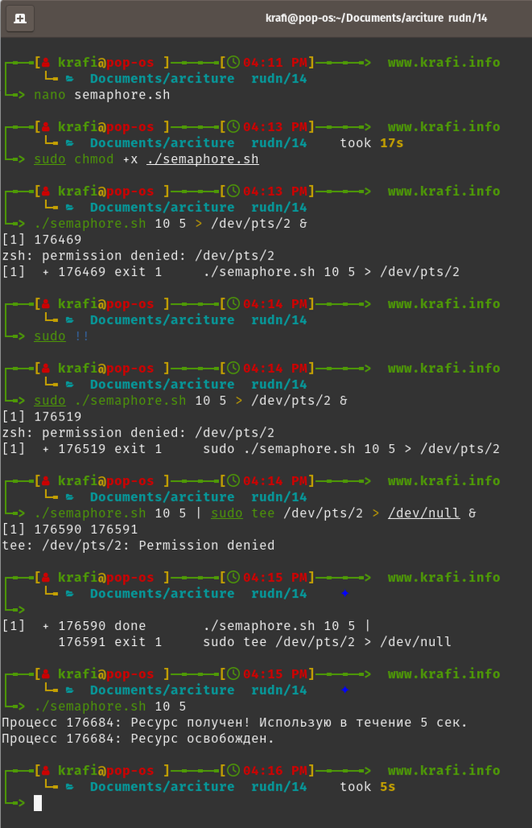

### **Задание 2: Реализация команды man**

**Листинг скрипта myman.sh:**

#!/bin/bash  
# Проверяем, передан ли аргумент  
if [ $# -eq 0 ]; then  
echo "Ошибка: Укажите имя команды для просмотра справки."  
echo "Пример: ./myman.sh ls"  
exit 1  
fi  
command_name=$1  
man_page_path="/usr/share/man/man1/${command_name}.1.gz"  
# Проверяем существование файла справки  
if [ -f "$man_page_path" ]; then  
# Если файл найден, открываем его с помощью less  
less "$man_page_path"  
elif [ -f "${man_page_path%.gz}" ]; then  
# На случай, если файл не запакован (без .gz)  
less "${man_page_path%.gz}"  
else  
echo "Справка для команды '$command_name' не найдена в /usr/share/man/man1/."  
exit 1  
fi

**Результат выполнения:**

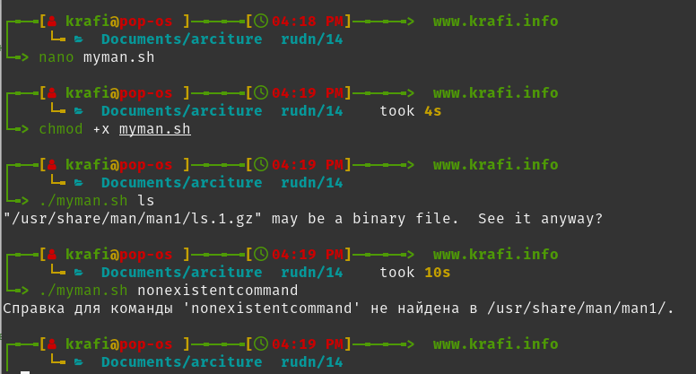

### **Задание 3: Генерация случайной последовательности букв**

**Листинг скрипта random_letters.sh:**

#!/bin/bash  
# Функция для генерации одной случайной буквы  
get_random_letter() {  
# Генерируем случайное число от 0 до 25 (26 букв)  
local random_num=$(( RANDOM % 26 ))  
# Преобразуем число в букву. 65 - код 'A' в ASCII, 97 - код 'a'  
# Для заглавных: printf "\x$(printf %x $((65 + random_num)))"  
printf "\x$(printf %x $((97 + random_num)))"  
}  
# Задаем длину последовательности (можно вынести в аргумент)  
length=10  
result=""  
# Цикл для генерации последовательности заданной длины  
for (( i=0; i<$length; i++ )); do  
# Конкатенируем буквы в строку  
result="${result}$(get_random_letter)"  
done  
echo "Случайная последовательность: $result"

**Альтернативная, более эффективная реализация с помощью массива:**

#!/bin/bash  
length=10  
declare -a letters  
for (( i=0; i<$length; i++ )); do  
random_num=$(( RANDOM % 26 ))  
# Заполняем массив кодами букв  
letters[i]=$((97 + random_num))  
done  
# Преобразуем массив кодов символов в реальную строку  
printf -v result "\x$(printf %x "${letters[@]}")"  
echo "Случайная последовательность: $result"

**Результат выполнения:**

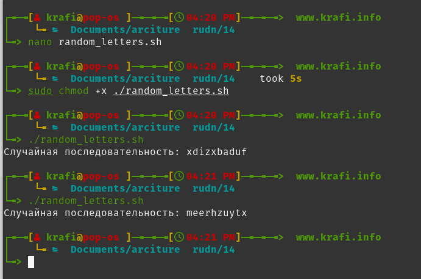

### **Ответы на контрольные вопросы**

4. > **Найдите синтаксическую ошибку в следующей строке:** while [$1 != "exit"] **Ошибка:** Недостаточно пробелов. Конструкция [ — это actually команда (синоним test), поэтому она требует пробелов вокруг себя и вокруг операторов. **Правильный вариант:** while [ "$1" != "exit" ]
5. > **Как объединить (конкатенация) несколько строк в одну?**
   - > **В переменную:** new_string="$string1$string2"
   - > **В выводе:** echo "$string1" "$string2"
   - > **С разделителем:** joined_string=$(printf "%s\n" "${array[@]}") для массива.
6. > **Найдите информацию об утилите seq. Какими иными способами можно реализовать её функционал?** **seq** генерирует последовательность чисел. **Аналоги на bash:**
   - > Цикл с C-подобным синтаксисом: for ((i=1; i<=5; i++)); do ... done
   - > Фигурные скобки: echo {1..5} (но это не итерация, а генерация списка).
   - > while-цикл с инкрементом счетчика.
7. > **Какой результат даст вычисление выражения $(10/3)?** Это вызовет ошибку, так как $(...) — это подстановка вывода команды. Команды 10/3 не существует. Для арифметических вычислений нужно использовать $((10/3)) (вернет 3).
8. > **Укажите кратко основные отличия командной оболочки zsh от bash.**
   - > **Zsh:** Более развитые возможности автодополнения (более умное и настраиваемое), смена каталога по имени без cd, глобальные псевдонимы, улучшенная обработка подстановки путей (globbing), темы для приглашения командной строки.
   - > **Bash:** Стандартная оболочка по умолчанию в большинстве дистрибутивов, более широко распространена, скрипты на bash более переносимы. Zsh часто используют как интерактивную оболочку, а bash — для системных скриптов.
9. > **Проверьте, верен ли синтаксис данной конструкции** for ((a=1; a <= LIMIT; a++)) **Да, синтаксис верен,** если переменная LIMIT предварительно определена. Это корректный C-подобный синтаксис для арифметического цикла в bash.
10. > **Сравните язык bash с какими-либо языками программирования.**
    - > **Преимущества bash:**
      - > Идеален для автоматизации вызова системных утилит (намного проще, чем на C/Python).
      - > Не требует компиляции, удобен для быстрого прототипирования.
      - > Встроенная работа с потоками данных (pipes, перенаправления).
    - > **Недостатки bash:**
      - > Медленнее компилируемых языков (C, Go).
      - > Неудобен для сложных структур данных (массивы, объекты) и алгоритмов.
      - > Чувствителен к пробелам и специальным символам, что может приводить к ошибкам.
      - > Отсутствие строгой типизации.